# EDA y modelos (datos de bebes)

Pedro J. Pérez (pedro.j.perez@uv.es). Universitat de València

# 1. IntroducciÃ³n

Hemos visto en tutoriales anteriores como cargar, manejar, arreglar y visualizar datos Ã la tidyverse. Una vez somos capaces de manejar y arreglar nuestros datos con R podemos pasar a efectuar un análisis “realista”� con un conjunto de datos.

En este tutorial y siguientes, vamos a utilizar un conjunto de datos sobre nacimientos de bebes en España para mostrar algunas técnicas de EDA y modelización. No se mostrarán los detalles técnicos de las métodos, sino solo su aplicación práctica y, a veces, la interpretación de los resultados.

Antes de proceder a la estimación de modelos estadísticos formales o contrastar hipótesis se suele realizar una etapa conocida como **análisis exploratorio**. El análisis exploratorio (EDA) es una parte importante de todo análisis de datos. Suele tener lugar antes de la especificación y estimación de modelos estadísticos formales. Su objetivo último es “comprender”� los datos y las relaciones existentes entre las variables.

Una de las máximas de un data scientist es, como señalan [aquí](https://medium.com/@Randy_Au/data-science-foundations-know-your-data-really-really-know-it-a6bb97eb991c?source=friends_link&sk=42f1c02883e744df7dbb618373312244), “**Know Your Data**”�. Además nos explican que:

> Data exploration is the art of looking at your data, rapidly generating hypotheses, quickly testing them, then repeating again and again and again. The goal of data exploration is to generate many promising leads that you can later explore in more depth.

> With exploratory data analysis, youâ€™ll combine visualisation and transformation with your curiosity and scepticism to ask and answer interesting questions about data

Un buen ejemplo de qué es un análisis exploratorio son los *screencast* de David Robinson: cada semana, David graba un vídeo en el que efectúa un análisis rápido de un conjunto de datos. Puedes verlos, en su canal de youtube ,[aquí](https://www.youtube.com/user/safe4democracy/videos). En [este repo](https://github.com/dgrtwo/data-screencasts) de Github tienes la transcripción, en ficheros `.Rmd`, del código que acaba utilizando en los screencasts. Hay bastante gente que sigue sus vídeos y , como explican en [este post](https://paulvanderlaken.com/2020/06/16/david-robinsons-r-programming-screencasts/), varias personas mantienen un listado en el que diseccionan las tareas que hace David en cada screencast, puedes encontrarlos [aquí](https://docs.google.com/spreadsheets/d/1pjj_G9ncJZPGTYPkR1BYwzA6bhJoeTfY2fJeGKSbOKM/edit#gid=444382177).

Por Ãºltimo, un buen libro, bueno un *bookdown*, sobre EDA: [Exploratory Data Analysis with R](https://bookdown.org/rdpeng/exdata/) de Roger Peng.

## ¿Qué queremos saber?

Generalmente un estudio cuantitativo comienza por una pregunta(s) que guía el análisis. En nuestro caso, el objetivo del tutorial es meramente mostrar algunas funciones y técnicas útiles en la fase de exploración de datos (EDA); aún así, durante el tutorial, nuestro “estudio”� estará guiado por varias preguntas relacionadas con los bebes; por ejemplo: 1) vamos a intentar ver/contestar si los bebitos nacen con más peso que las bebitas, y 2) intentaremos contestar a la pregunta de si determinadas características de las madres/padres, como la edad o el nivel educativo, afectan al peso de los recién nacidos.

El siguiente paso de todo análisis empírico es la búsqueda de un conjunto de datos que permita (hasta cierto grado de confianza) dar una respuesta a las preguntas planteadas. ¿De donde sacamos esos datos? En nuestro caso, utilizaremos la estadística de nacimientos del INE. Los detalles en la sección siguiente.

# 2. Los datos

## Origen de los datos

Los datos provienen del **INE**, concretamente de la [**Estadística de nacimientos**](http://www.ine.es/dyngs/INEbase/es/operacion.htm?c=Estadistica_C&cid=1254736177007&menu=resultados&secc=1254736195443&idp=1254735573002). Como puedes ver en la web del INE hay una serie de tablas que muestran resultados para las principales variables; por ejemplo, hay una tabla llamada [“Nacimientos por edad de la madre, mes y sexo”�](https://www.ine.es/jaxi/Tabla.htm?path=/t20/e301/provi/l0/&file=01001.px&L=0). Estas tablas están muy bien para mostrar los principales resultados de la Estadística de nacimientos, pero nosotros queremos analizar “de verdad”� los datos, así que tendremos que descargarnos los [**microdatos** de la encuesta](https://www.ine.es/dyngs/INEbase/es/operacion.htm?c=Estadistica_C&cid=1254736177007&menu=resultados&secc=1254736195443&idp=1254735573002#!tabs-1254736195443).

En los microdatos de la Estadística de Nacimientos hay datos sobre: (i) Nacimientos, (ii) Muertes fetales tardías y (iii) Partos. Vamos a usar los ficheros de datos sobre **PARTOS**. Hay un fichero para cada año desde 1975, pero como han habido diversos cambios en la metodología de la estadística, solo vamos a trabajar los ficheros de los años **2007 a 2019** que comparten diccionario.

Los datos eran de partos, pero los preparÃ© para que cada fila pertenezca a los datos de un solo bebe: **cada bebe tiene su propia fila**.

## Cargando el fichero de datos y dicc

Ya dijimos que los datos provienen del **INE**, concretamente de la [**Estadística de nacimientos**](http://www.ine.es/dyngs/INEbase/es/operacion.htm?c=Estadistica_C&cid=1254736177007&menu=resultados&secc=1254736195443&idp=1254735573002). He restringido la muestra a los partos en la Comunitat Valenciana para los años 2016 y 2019.

```r
#- Cargo datos q voy a usar y el diccionario.
mys_archivos <- fs::dir_ls(here::here("datos", "usar"))         #- AQUI
dicc_df_all <- readxl::read_excel(mys_archivos[[2]])
df_all <-  readr::read_rds(mys_archivos[[1]])
```

Los datos tienen: **107 variables y 79830** registros de bebes. Tenemos datos para los años: **2016 y 2019**. Hay muchas variables, iremos seleccionado las variables que nos interesan para cada visulización

## Diccionario

Lo primero es conocer tus variables, para ello tiene que haber un diccionario y lo hay, pero en nuestro caso el nombre de las variables (casÃ) es suficiente.

```r
names(df_all)
```

```
#>   [1] "prov_inscrip"                       "prov_inscrip.n"
#>   [3] "muni_inscrip"                       "muni_inscrip.n"
#>   [5] "year_parto"                         "fecha_parto"
#>   [7] "prov_parto"                         "prov_parto.n"
#>   [9] "muni_parto"                         "muni_parto.n"
#>  [11] "lugar_parto.f"                      "parto_asistido.f"
#>  [13] "nn_nacidos_parto_con_o_sin_vida"    "parto_normal.f"
#>  [15] "parto_cesarea.f"                    "parto_37_semanas.f"
#>  [17] "parto_nn_semanas"                   "fecha_nac_madre"
#>  [19] "nacionalidad_esp_madre"             "pais_nacionalidad_madre.n"
#>  [21] "nacionalidad_madre_cuando.f"        "prov_nac_madre"
#>  [23] "prov_nac_madre.n"                   "muni_nac_madre"
#>  [25] "muni_nac_madre.n"                   "pais_naci_madre.n"
#>  [27] "prov_res_madre"                     "prov_res_madre.n"
#>  [29] "muni_res_madre"                     "muni_res_madre.n"
```

[output cut: 39 more lines]

## 2 tablas

- Hago **2 tablas** para poder buscar las variables de forma rápida y ver sus principales características, aunque lo mejor es usar `dicc_df_all` ya sea en el Global o el diccionario original en local:

```r
dicc_show_1 <- dicc_df_all %>%
  select(variable, type, nn_unique, unique_values, p_na, p_zeros) %>%
  mutate(unique_values = stringr::str_sub(unique_values, 1, 45))
```

- 1. Tabla con `DT`

```r
DT::datatable(dicc_show_1, filter = 'top', extensions = "Scroller",
              options = list(autoWidth = TRUE,deferRender = TRUE,
                             scroller = TRUE, scrollY = 450 ))
```

|  | variable | type | nn_unique | unique_values | p_na | p_zeros |
| --- | --- | --- | --- | --- | --- | --- |
| 1 | prov_inscrip | character | 3 | 03 - 12 - 46 | 0 | 0 |
| 2 | prov_inscrip.n | character | 3 | Alicante/Alacant - Castellón/Castelló - Valen | 0 | 0 |
| 3 | muni_inscrip | character | 101 | NA - 03005 - 03009 - 03011 - 03014 - 03015 - | 14.09 | 0 |
| 4 | muni_inscrip.n | character | 101 | NA - AlaquÃ s - Albal - Albatera - Alberic - A | 14.09 | 0 |
| 5 | year_parto | character | 2 | 2016 - 2019 | 0 | 0 |
| 6 | fecha_parto | POSIXct | 24 | 2016-01-01 - 2016-02-01 - 2016-03-01 - 2016-0 | 0 | 0 |
| 7 | prov_parto | character | 25 | 02 - 03 - 04 - 06 - 07 - 08 - 11 - 12 - 13 - | 0 | 0 |
| 8 | prov_parto.n | character | 25 | Albacete - Alicante/Alacant - Almería - Badaj | 0 | 0 |
| 9 | muni_parto | character | 142 | NA - 02003 - 02009 - 02081 - 03005 - 03009 - | 1.1 | 0 |
| 10 | muni_parto.n | character | 142 | NA - AlaquÃ s - Albacete - Albal - Albatera - | 1.1 | 0 |

[output cut: 97 more lines]

- 2. Tabla con `reactable`

```r
# Tabla con el paquete [`reactable`](https://glin.github.io/reactable/index.html)
dicc_show_2 <- dicc_df_all %>%
  select(variable, type, nn_unique, unique_values, p_na, p_zeros)

library(reactable)
reactable::reactable(dicc_show_2, pagination = FALSE, height = 450, filterable = TRUE, searchable = TRUE, highlight = TRUE, columns = list( variable = colDef(
     # sticky = "left",
      # Add a right border style to visually distinguish the sticky column
      style = list(borderRight = "1px solid #eee"),
      headerStyle = list(borderRight = "1px solid #eee")
    )),
  defaultColDef = colDef(minWidth = 70)
)
```

| variable | type | nn_unique | unique_values | p_na | p_zeros |
| --- | --- | --- | --- | --- | --- |
| prov_inscrip | character | 3 | 03 - 12 - 46 | 0 | 0 |
| prov_inscrip.n | character | 3 | Alicante/Alacant - Castellón/Castelló - Valencia/València | 0 | 0 |
| muni_inscrip | character | 101 | NA - 03005 - 03009 - 03011 - 03014 - 03015 - 03018 - 03019 - 03031 - 03041 - 03047 - 03049 - 03050 - | 14.09 | 0 |
| muni_inscrip.n | character | 101 | NA - AlaquÃ s - Albal - Albatera - Alberic - Alboraia/Alboraya - AlcÃ sser - Alcora, l' - Alcoy/Alcoi | 14.09 | 0 |
| year_parto | character | 2 | 2016 - 2019 | 0 | 0 |
| fecha_parto | POSIXct | 24 | 2016-01-01 - 2016-02-01 - 2016-03-01 - 2016-04-01 - 2016-05-01 - 2016-06-01 - 2016-07-01 - 2016-08-0 | 0 | 0 |
| prov_parto | character | 25 | 02 - 03 - 04 - 06 - 07 - 08 - 11 - 12 - 13 - 16 - 17 - 18 - 21 - 22 - 23 - 28 - 30 - 31 - 37 - 41 - | 0 | 0 |
| prov_parto.n | character | 25 | Albacete - Alicante/Alacant - Almería - Badajoz - Balears, Illes - Barcelona - Cádiz - Castellón/Cas | 0 | 0 |
| muni_parto | character | 142 | NA - 02003 - 02009 - 02081 - 03005 - 03009 - 03014 - 03015 - 03018 - 03019 - 03031 - 03041 - 03047 - | 1.1 | 0 |
| muni_parto.n | character | 142 | NA - AlaquÃ s - Albacete - Albal - Albatera - Alberic - Alboraia/Alboraya - Alcañiz - Alcora, l' - Al | 1.1 | 0 |

[output cut: 97 more lines]

## Datos simplificados

Para que todo vaya mÃ¡s fluido vamos a utilizar un fichero de datos reducido:

Al final, las variables que usaremos son:

```r
#- Al final usaremos estas variables
df <- df_2
names(df)
```

```
#>  [1] "fecha_parto"               "prov_inscrip.n"
#>  [3] "tamanyo_muni_inscri.f"     "parto_cesarea.f"
#>  [5] "parto_normal.f"            "parto_nn_semanas"
#>  [7] "sexo_bebe.f"               "peso_bebe"
#>  [9] "pais_nacionalidad_madre.n" "edad_madre.1"
#> [11] "estudios_madre.ff"         "pais_nacionalidad_padre.n"
#> [13] "edad_padre.1"              "estudios_padre.ff"
#> [15] "nn_hijos_tot"
```

Vamos a tener **15 variables** y **79830 bebes**

Hagamos un diccionario para la base de datos reducida que al final usaremos:

```r
#- creo dicc. de los daros q voy a USAR
df_aa <- pjpv2020.01::pjp_f_estadisticos_basicos(df)
df_bb <- pjpv2020.01::pjp_f_unique_values(df, truncate = TRUE, nn_truncate = 50)
dicc_df <- bind_cols(df_aa, df_bb)
dicc_df <- dicc_df %>% select(variable, type, nn_unique, unique_values, q_na, p_na, p_zeros, min, max, mean, sd, NN, NN_ok)
```

```r
DT::datatable(dicc_df, filter = 'top', extensions = "Scroller", options = list(
    autoWidth = TRUE,
    deferRender = TRUE,
    scroller = TRUE,
    scrollY = 500
))
```

|  | variable | type | nn_unique | unique_values | q_na | p_na | p_zeros | min | max | mean | sd | NN | NN_ok |
| --- | --- | --- | --- | --- | --- | --- | --- | --- | --- | --- | --- | --- | --- |
| 1 | fecha_parto | POSIXct | 24 | 2016-01-01 - 2016-02-01 - 2016-03-01 - 2016-04-01 | 0 | 0 | 0 |  |  |  |  | 79830 | 79830 |
| 2 | prov_inscrip.n | character | 3 | Alicante/Alacant - Castellón/Castelló - Valencia/V | 0 | 0 | 0 |  |  |  |  | 79830 | 79830 |
| 3 | tamanyo_muni_inscri.f | factor | 6 | [ 0 - 10.000] - [10.001 - 20.000] - [20.001 - 50.0 | 0 | 0 | 0 |  |  |  |  | 79830 | 79830 |
| 4 | parto_cesarea.f | factor | 2 | Sin cesárea - Con cesárea | 0 | 0 | 0 |  |  |  |  | 79830 | 79830 |
| 5 | parto_normal.f | factor | 2 | Parto normal - Parto con complicaciones | 0 | 0 | 0 |  |  |  |  | 79830 | 79830 |
| 6 | parto_nn_semanas | numeric | 28 | NA - 20 - 21 - 22 - 23 - 24 - 25 - 26 - 27 - 28 - | 6835 | 8.56 | 0 | 20 | 46 | 38.85 | 1.98 | 79830 | 72995 |
| 7 | sexo_bebe.f | factor | 2 | bebita - bebito | 0 | 0 | 0 |  |  |  |  | 79830 | 79830 |
| 8 | peso_bebe | numeric | 1974 | NA - 390 - 400 - 430 - 450 - 500 - 510 - 520 - 525 | 3016 | 3.78 | 0 | 390 | 6335 | 3202.81 | 550.87 | 79830 | 76814 |
| 9 | pais_nacionalidad_madre.n | character | 64 | NA - Alemania - Angola - Argelia - Argentina - Arm | 454 | 0.57 | 0 |  |  |  |  | 79830 | 79376 |
| 10 | edad_madre.1 | numeric | 1657 | 13.5824777549624 - 13.8288843258042 - 13.919233401 | 0 | 0 | 0 | 13.58 | 53.92 | 33.02 | 5.58 | 79830 | 79830 |

[output cut: 5 more lines]

# 3. Cosas de EDA

Hemos visto en tutoriales anteriores como cargar, arreglar y manejar datos con R *Ã la tidyverse*. En este tutorial vamos a ver **algunos paquetes y funciones que conviene conocer porque nos pueden ayudar a acelerar el anÃ¡lisis exploratorio inicial de nuestros datos**.

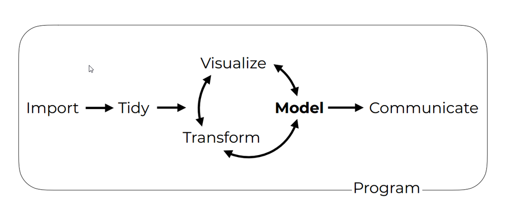

En este [repo de Github](https://github.com/mstaniak/autoEDA-resources), Mateusz Staniak mantiene un listado de paquetes y recursos relacionados con la EDA.

En [este post](http://smarterpoland.pl/index.php/2019/04/explore-the-landscape-of-r-packages-for-automated-data-exploration/) y en [este artículo](https://arxiv.org/pdf/1904.02101.pdf) nos hablan del paquete [`autoEDA`](https://github.com/XanderHorn/autoEDA) que trata de automatizar el proceso inicial exploratorio de datos (EDA). Además el post nos muestra los 11 paquetes de R, relacionados con la EDA, más descargados de CRAN. El objetivo de estos 11/12 paquetes es similar, tratar de automatizar/facilitar el análisis preliminar o exploratorio de los datos (EDA). Evidentemente automatizar totalmente la EDA es muy-muy complicado, por no decir imposible, pero al menos estos paquetes (y otros muchos) contienen funciones que nos pueden ayudar en las primeras etapas de nuestros análisis de datos.

Por ejemplo, en [este post](https://www.littlemissdata.com/blog/simple-eda), Laura Ellis, nos explica como hacer EDA en R mostrándonos algunas de sus funciones/trucos favoritos como la función `skimr::skim()`, `visdat::vis_dat()` o `DataExplorer::create_report()`. El post tuvo una segunda parte ([aquí](https://www.littlemissdata.com/blog/inspectdf)), donde Laura nos explica el uso de algunas funciones útiles para EDA del paquete [`inspectdf`](https://github.com/alastairrushworth/inspectdf) como por ejemplo: `inspectdf::inspect_types()`, `inspectdf::inspect_na`, etc…

En este [otro post](https://sharla.party/posts/new-data-strategies/), Sharla Gelfand nos habla sobre estrategias para afrontar la EDA cuando se trabaja con un conjunto de datos nuevo. Sharla utiliza, entre otros, los paquetes [`visdat`](http://visdat.njtierney.com/), [`skimr`](https://ropensci.github.io/skimr/) y [`assertr`](https://docs.ropensci.org/assertr/).

Un [post mÃ¡s reciente](https://yuzar-blog.netlify.app/posts/2021-01-09-exploratory-data-analysis-and-beyond-in-r-in-progress/), de 2021, nos habla de 3 paquetes que hacen informes exploratorios completos de los datos: [DataExplorer](http://boxuancui.github.io/DataExplorer/), [SmartEDA](https://daya6489.github.io/SmartEDA/) y [dlookr](https://choonghyunryu.github.io/dlookr/).

De entre los muchos paquetes y funciones relacionados con EDA, conviene conocer, en mi opiniÃ³n, estos[^1]:

## 3.0 Informes completos

Hay varios paquetes que permiten realizar informes completos de un dataset de forma completamente automatizada. Por ejemplo:

- Con el paquete [DataExplorer](http://boxuancui.github.io/DataExplorer/)

```r
# informe sin especificar variable objetivo
DataExplorer::create_report(df)

# informe con  variable objetivo
create_report(df, y = "peso_bebe")
create_report(df, y = "sexo_bebe.f")
```

- Con el paquete [dlookr](https://choonghyunryu.github.io/dlookr/)

```r
dlookr::diagnose_report(df)

# informe con variable objetivo
dlookr::eda_report(df, target = peso_bebe,
                   output_format = "html", output_file = "EDA_bebes.html")

# ejemplo con NA's
dlookr::transformation_report(df, target = peso_bebe)

# ejemplo con  outliers
transformation_report(df, target = peso_bebe)
```

- Con el paquete [SmartEDA](https://daya6489.github.io/SmartEDA/)

```r
SmartEDA::ExpReport(df, op_file = 'smarteda.html')

# informe con variable objetivo
SmartEDA::ExpReport(df, op_file = 'smarteda.html', Target = "peso_bebe")
```

- Con el paquete summarytools

```r
summarytools::dfSummary(df)
```

## 3.1 Nombres de las variables

Podemos cambiar y ver el nombre de las variables de varias maneras:

- Con `dplyr::rename()`

```r
df_copy <- df %>% dplyr::rename(peso_bebe_nuevo = peso_bebe)
names(df_copy)[1] <- paste0(names(df_copy)[1], "_new") #- cambio el primer nombre
```

- Con `base::names()`

```r
names(df_copy)[1] <- paste0(names(df_copy)[1], "_new") #- cambio el primer nombre
names(df_copy)[2] <- "nuevo_nombre"    #- cambio el nombre de la segunda variable
```

- la función `janitor::clean_names()` arregla automáticamente los nombres de las variables, lo que pasa es que es nuestro ejemplo los nombres ya están suficientemente arreglados, pero si tuviésemos un data.frame con nombres extraños, muy largos o incluso con nombres “no sintácticos”�, y necesitaramos arreglarlos de forma rápida, podemos hacerlo con la función `janitor::clean_names()`, que arregla los nombres de las variables de forma automática, y además tiene algunas opciones para hacerlo como más te guste.

```r
janitor::clean_names(df)
```

## 3.2 Estructura y tipo de variables

Siempre-siempre hay que saber de que tipo son nuestras variables. Esto se puede hacer de muchas formas. Os muestro dos:

### a) con `str()`

```r
str(df)            #- str() muestra la estructura interna de un objeto R
```

```
#> tibble [79,830 Ã— 15] (S3: tbl_df/tbl/data.frame)
#>  $ fecha_parto              : POSIXct[1:79830], format: "2016-01-01" "2016-01-01" ...
#>  $ prov_inscrip.n           : chr [1:79830] "Valencia/ValÃ¨ncia" "CastellÃ³n/CastellÃ³" "Valencia/ValÃ¨ncia" "Valencia/ValÃ¨ncia" ...
#>  $ tamanyo_muni_inscri.f    : Factor w/ 6 levels "[ 0 - 10.000]",..: 3 1 3 2 6 6 1 4 6 2 ...
#>  $ parto_cesarea.f          : Factor w/ 2 levels "Sin cesÃ¡rea",..: 1 1 1 2 1 2 2 1 2 1 ...
#>  $ parto_normal.f           : Factor w/ 2 levels "Parto normal",..: 1 1 1 1 1 2 2 1 2 2 ...
#>  $ parto_nn_semanas         : num [1:79830] 23 26 25 25 27 27 25 26 30 27 ...
#>  $ sexo_bebe.f              : Factor w/ 2 levels "bebita","bebito": 1 1 1 1 2 1 2 2 1 2 ...
#>  $ peso_bebe                : num [1:79830] 560 565 685 750 750 800 850 960 1000 1030 ...
#>  $ pais_nacionalidad_madre.n: chr [1:79830] "EspaÃ±a" "EspaÃ±a" "EspaÃ±a" "Bulgaria" ...
#>  $ edad_madre.1             : num [1:79830] 41.2 27 26.5 25.5 35.7 ...
#>  $ estudios_madre.ff        : Factor w/ 3 levels "Primarios","Medios",..: 2 1 2 1 2 3 2 NA 2 2 ...
#>  $ pais_nacionalidad_padre.n: chr [1:79830] "EspaÃ±a" "EspaÃ±a" "EspaÃ±a" "Bulgaria" ...
#>  $ edad_padre.1             : num [1:79830] 47.4 34.8 30.1 27 37.9 ...
#>  $ estudios_padre.ff        : Factor w/ 3 levels "Primarios","Medios",..: 2 1 2 1 2 3 2 NA 2 1 ...
#>  $ nn_hijos_tot             : num [1:79830] 1 3 1 1 1 1 2 1 1 1 ...
```

### b) con `inspectdf::inspect_types()`

```r
inspectdf::inspect_types(df)   #- muestra de que tipo son las variables
```

```
#> # A tibble: 4 Ã— 4
#>   type             cnt  pcnt col_name
#>   <chr>          <int> <dbl> <named list>
#> 1 factor             6 40    <chr [6]>
#> 2 numeric            5 33.3  <chr [5]>
#> 3 character          3 20    <chr [3]>
#> 4 POSIXct POSIXt     1  6.67 <chr [1]>
```

## 3.3 Valores Ãºnicos de las variables

Conviene saber qué valores (únicos) tienen las distintas variables de una tabla de datos; por ejemplo, es obvio, pero hay que saber cual es el periodo muestral de nuestros datos y el hecho de que nuestros datos los trabajemos habitualmente en formato largo, hace que saber esto no sea tan-tan sencillo

- `pjpv2020.01::pjp_f_unique_values()` devuelve un df con los valores Ãºnicos de cada variable:

```r
zz <- pjpv2020.01::pjp_f_unique_values(df, truncate = TRUE, nn_truncate = 47)
gt::gt(zz)
```

| variables | nn_unique | unique_values |
| --- | --- | --- |
| fecha_parto | 24 | 2016-01-01 - 2016-02-01 - 2016-03-01 - 2016-04- |
| prov_inscrip.n | 3 | Alicante/Alacant - Castellón/Castelló - Valenci |
| tamanyo_muni_inscri.f | 6 | [ 0 - 10.000] - [10.001 - 20.000] - [20.001 - 5 |
| parto_cesarea.f | 2 | Sin cesárea - Con cesárea |
| parto_normal.f | 2 | Parto normal - Parto con complicaciones |
| parto_nn_semanas | 28 | NA - 20 - 21 - 22 - 23 - 24 - 25 - 26 - 27 - 28 |
| sexo_bebe.f | 2 | bebita - bebito |
| peso_bebe | 1974 | NA - 390 - 400 - 430 - 450 - 500 - 510 - 520 - |
| pais_nacionalidad_madre.n | 64 | NA - Alemania - Angola - Argelia - Argentina - |
| edad_madre.1 | 1657 | 13.5824777549624 - 13.8288843258042 - 13.919233 |
| estudios_madre.ff | 4 | NA - Primarios - Medios - Universidad |
| pais_nacionalidad_padre.n | 64 | NA - Alemania - Angola - Argelia - Argentina - |
| edad_padre.1 | 2034 | NA - 14.8281998631075 - 15.0006844626968 - 15.2 |
| estudios_padre.ff | 4 | NA - Primarios - Medios - Universidad |
| nn_hijos_tot | 12 | 1 - 2 - 3 - 4 - 5 - 6 - 7 - 8 - 9 - 10 - 11 - 1 |

```r
zz <- pjpv2020.01::pjp_f_valores_unicos(df)
gt::gt(zz)
```

- La función `dplyr::distinct()` es muy útil para ver los con valores únicos de una o varias variables. Por ejemplo:

```r
names(df)
```

```
#>  [1] "fecha_parto"               "prov_inscrip.n"
#>  [3] "tamanyo_muni_inscri.f"     "parto_cesarea.f"
#>  [5] "parto_normal.f"            "parto_nn_semanas"
#>  [7] "sexo_bebe.f"               "peso_bebe"
#>  [9] "pais_nacionalidad_madre.n" "edad_madre.1"
#> [11] "estudios_madre.ff"         "pais_nacionalidad_padre.n"
#> [13] "edad_padre.1"              "estudios_padre.ff"
#> [15] "nn_hijos_tot"
```

```r
zz <- df %>% distinct(prov_inscrip.n, parto_cesarea.f)
zz %>% gt::gt()
```

| prov_inscrip.n | parto_cesarea.f |
| --- | --- |
| Valencia/València | Sin cesárea |
| Castellón/Castelló | Sin cesárea |
| Valencia/València | Con cesárea |
| Castellón/Castelló | Con cesárea |
| Alicante/Alacant | Con cesárea |
| Alicante/Alacant | Sin cesárea |

## 3.4 Estadísticos básicos de las variables

### a) con `pjpv2020.01::pjp_f_estadisticos_basicos()`

La función `pjpv2020.01::pjp_f_estadisticos_basicos()`. Sí, el nombre de la función es un poco largo, pero es que es un paquete para uso personal. Yo estoy acostumbrado a usarla. Da un resumen rápido de las variables del data.frame:

```r
zz <- pjpv2020.01::pjp_f_estadisticos_basicos(df)   #- estadÃsticos bÃ¡sicos del df
zz <- pjpv2020.01::pjp_f_unique_values(df)          #- valores Ãºnicos de cada variable de df
```

### b) con `summarytools::dfSummary()`

La función `summarytools::dfSummary()` da un informe/resumen de las variables de un data.frame muy útil. Es muy útil para hacerse una idea rápida de las propiedades de las variables, pero tiene la pega de que el output es muy voluminosos para mostrarlo aquí, así que si quieres verlo tendrás que ejecutar el anterior chunk de forma interactiva.

```r
zz <- summarytools::dfSummary(df) #- genera un fichero con un resumen Ãºtil y agradable de ver
summarytools::view(zz)  #- para visualizar el informe
```

### c) con `skimr::skim()`

Otra alternativa es usar `skimr::skim(df). Ocurre lo mismo: como su output es voluminoso, no lo voy a mostrar aquÃ.

```r
skimr::skim(df)
```

### d) con `gtsummary::tbl_summary()`

```r
gtsummary::tbl_summary(df)
```

Además esta función permite especificar variables de agrupación y realizar algunos contrastes. Para ver todas las posibilidades que ofrece, la vignette está [aquí](https://www.danieldsjoberg.com/gtsummary/articles/tbl_summary.html)

```r
df %>% select(peso_bebe, parto_nn_semanas, estudios_madre.f, parto_cesarea.f) %>%
  gtsummary::tbl_summary(by = "parto_cesarea.f") %>%
  gtsummary::add_p()
names(df)
```

## 3.5 NAâ€™s

Siempre hay que chequear la existencia de **NA’s** en nuestro df. NA representa una característica que existe pero no sabemos su valor En R, los valores no disponibles se representan con `NA`. Se puede chequear si un valor es NA con la función `is.na()`. En datos generados por otros paquetes estadísticos, los valores ausentes pueden estar codificados con diferentes valores como por ejemplo “-999”�, “N/A”�, un espacio en blanco, etc …

Unas [slides](https://docs.google.com/presentation/d/1EzMU6be01aicPGeBcbXrXy1iX8CdWhBz1o2pJDPsXBM/edit?usp=sharing) de `@allison_horst` que ayudan a entender los distintos tipos de NA’s. Además [aquí](https://ucsb.box.com/s/pr2z7ygeycrfwefmsdknrq3lurzka5u) está el video y un tutorial interactivo [aquí](https://allisonhorst.shinyapps.io/missingexplorer/)

Cuatro paquetes que nos pueden ayudar en esta tarea son `DataExplorer`, `visdat` , `naniar` y `dlookr`.

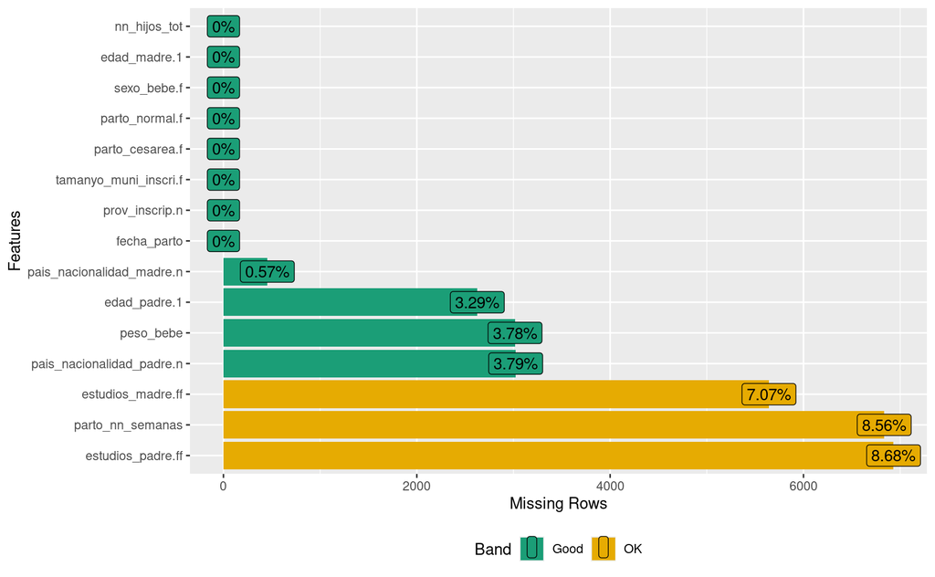

```r
DataExplorer::plot_missing(df)
```

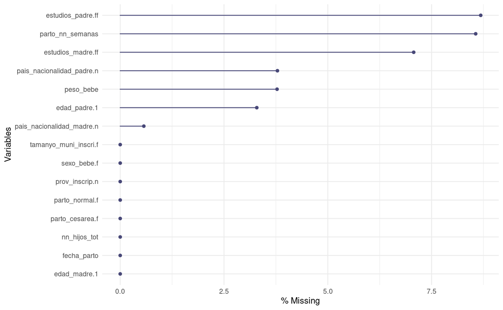

```r
naniar::gg_miss_var(df, show_pct = TRUE)
```

El paquete `visdat` es útil para ver los NA’s pero el siguiente chunk no nos va a funcionar para las 79.830 filas que tiene nuestro df.

```r
visdat::vis_dat(df) #- no funciona , hay demasiadas filas
```

Pero veamos como funcionarÃa para, por ejemplo, las primeras 1.000 filas de df:

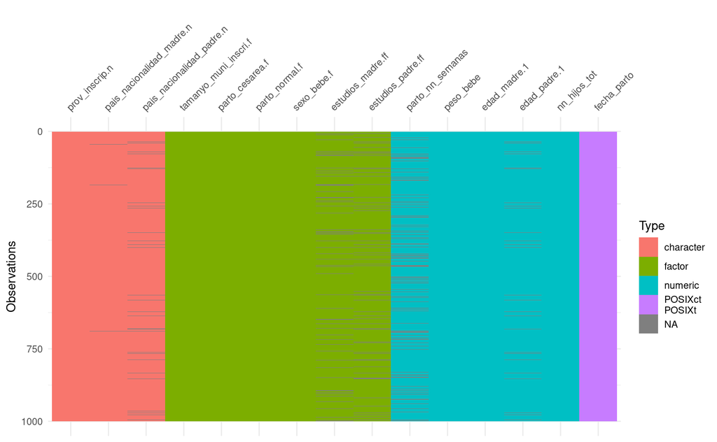

```r
df %>% slice(1:1000) %>% visdat::vis_dat()
```

- Algo parecido pero con `visdat::vis_miss()`

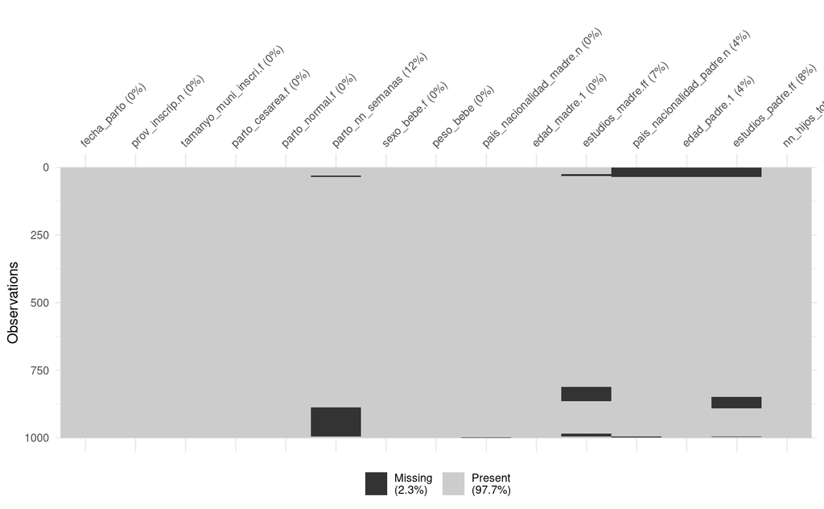

```r
df %>% slice(1:1000) %>% visdat::vis_miss(cluster = TRUE)
```

- Otra forma de visualizar la **co-ocurrencia de NAâ€™s** en las variables de df:

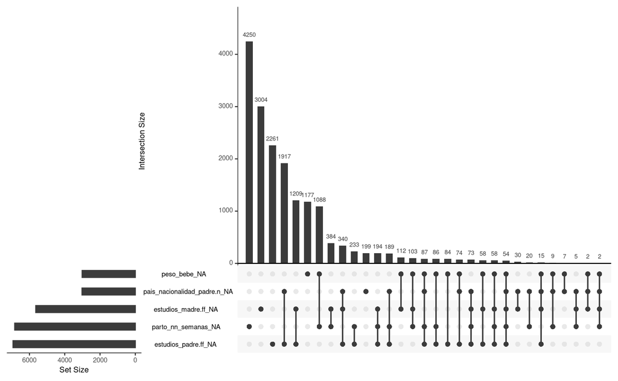

```r
naniar::gg_miss_upset(df)
```

- `dlookr::plot_na_intersect()` proporciona un gráfico muy útil. Nos ofrece las variables que tienen NA’s y la co-ocurrencia de NA’s entre ellas.

```r
dlookr::plot_na_intersect(df)
```

### Trabajando con los `NA's`

- Por ejemplo, podemos querer seleccionar las variables que tienen NAâ€™s:

```r
zz_con_NAs  <- df %>% select(where(anyNA))
```

- A lo mejor, nos puede interesar ver la ocurrencia de NA’s para los grupos/categorías de una variable categórica de df, por ejemplo los estudios de la madre(`estudios_madre.f`)

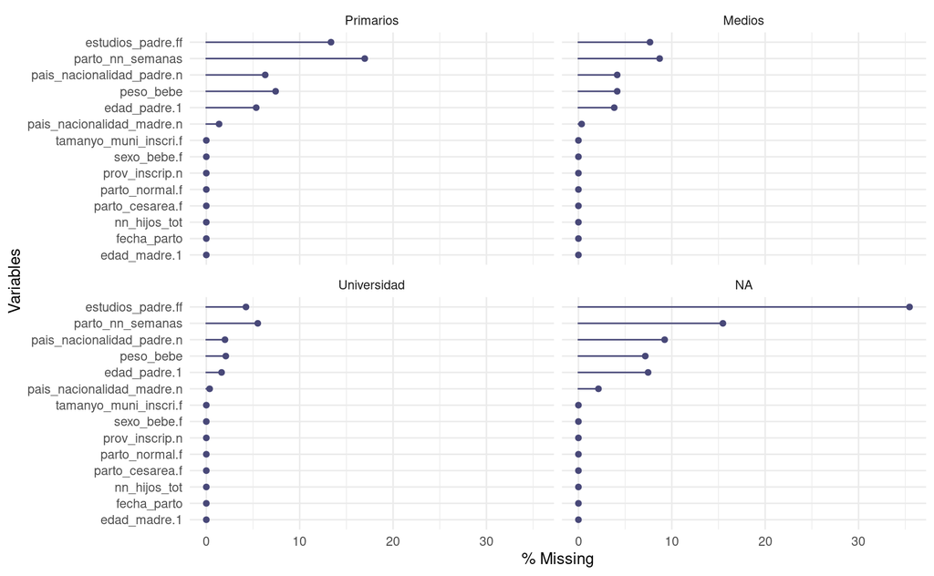

```r
naniar::gg_miss_var(df, facet = estudios_madre.ff, show_pct = TRUE) #- faceted por la variable estudios_madre.ff
```

### ¿Que hacemos con los NA’s?

Pues no está claro, depende … pero supongamos que queremos dejar nuestro df **SIN NA’s;**

```r
zz <- df %>% tidyr::drop_na()              #- con tidyr

#- otras formas de hacer lo mismo ---
zz <- df[complete.cases(df), ]             #- con base-R
zz <- df %>% filter(complete.cases(.))     #- con dplyr y base-R
```

Si quitáramos todos los registros/bebes que tienen algún NA en alguna de las 15 variables, nos quedaríamos con 62.348 registros.

Se puede refinar la eliminación de `NA's`. Puedes ser que igual Igual nos interesase eliminar sólo las filas que tengan un `NA` en una determinada variable, por ejemplo, si quisieramos quitar las filas que tuviesen NA en la variable `peso_bebe` y/o en la variable `parto_nn_semanas`, lo haríamos así:

```r
zz <- df %>% tidyr::drop_na(c(peso_bebe, parto_nn_semanas))   #- quito filas con NA en peso_bebe o en SEMANAS
```

- Imagina que hubiese una fila o una columna con todos sus valores NA. Lógicamente habría que eliminarlas. Se puede hacer fácil con `janitor::remove_empty()

```r
zz <- df %>% janitor::remove_empty(c("rows", "cols"))    #- quita variables y filas vacÃas
```

## 3.6 Variables numÃ©ricas

Vamos a ver algunas funciones útiles para hacer un análisis inicial de las variables numéricas.

Si quisiéramos crear un df sólo con las variables numéricas:

```r
df_numeric <- df %>% select_if(is.numeric)      #- antigua sintaxis
df_numeric <- df %>% select(where(is.numeric))  #- nueva API
```

### a) EstadÃsticos descriptivos

Por ejemplo, `summarytools::descr()` nos ayuda a calcular rápidamente estadísticos descriptivos de las variables numéricas.

```r
summarytools::descr(df, style = "rmarkdown")
```

```r
summarytools::descr(df)
```

```
#> Descriptive Statistics
#> df
#> N: 79830
#>
#>                     edad_madre.1   edad_padre.1   nn_hijos_tot   parto_nn_semanas   peso_bebe
#> ----------------- -------------- -------------- -------------- ------------------ -----------
#>              Mean          33.02          36.09           1.72              38.85     3202.81
#>           Std.Dev           5.58           6.12           0.87               1.98      550.87
#>               Min          13.58          14.83           1.00              20.00      390.00
#>                Q1          29.67          32.33           1.00              38.00     2910.00
#>            Median          33.50          36.08           2.00              39.00     3240.00
#>                Q3          36.91          39.75           2.00              40.00     3550.00
#>               Max          53.92          73.49          12.00              46.00     6335.00
#>               MAD           5.31           5.56           1.48               1.48      474.43
#>               IQR           7.25           7.42           1.00               2.00      640.00
#>                CV           0.17           0.17           0.51               0.05        0.17
#>          Skewness          -0.40           0.19           1.80              -2.43       -0.74
#>       SE.Skewness           0.01           0.01           0.01               0.01        0.01
#>          Kurtosis           0.10           1.02           6.54              11.04        2.12
#>           N.Valid       79830.00       77204.00       79830.00           72995.00    76814.00
#>         Pct.Valid         100.00          96.71         100.00              91.44       96.22
```

### b) Histogramas o f.Â de densidad

En general, los métodos estadísticos requieren que las variables sigan una determinada distribución. Esto puede chequearse formalmente o utilizar histogramas y/o funciones de densidad estimadas.

Podemos usar el paquete `DataExplorer` para obtener histogramas o gráficos de densidad para las variables numéricas.

- Histogramas:

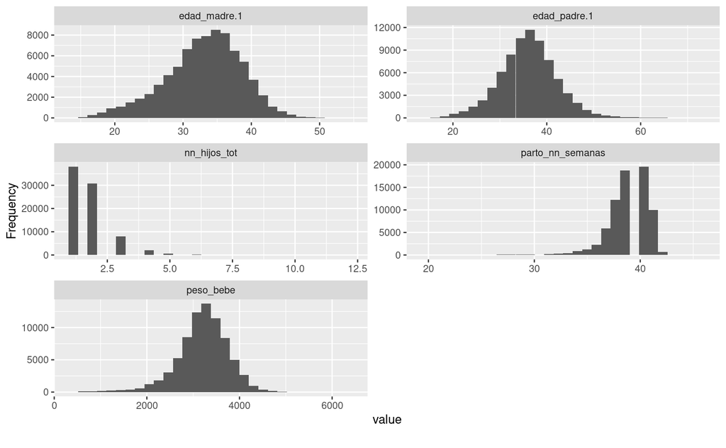

```r
DataExplorer::plot_histogram(df, ncol = 2)
```

- Funciones de densidad estimadas:

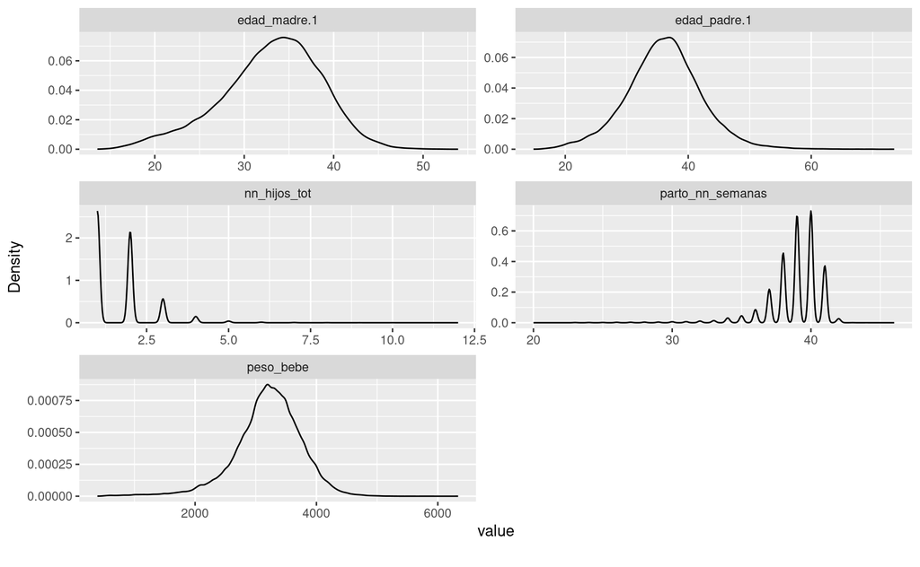

```r
DataExplorer::plot_density(df, ncol = 2)
```

### c) Matriz de correlaciones

Otro aspecto importante de un análisis exploratorio consiste en analizar la existencia de relaciones entre las variables del conjunto de datos. Esto puede hacerse de diversas maneras, dos de las más sencillas y usadas son los gráficos de dispersión y las matrices de correlación.

Podemos obtener la matriz de correlaciones de diversas formas:

- Primero con la funciÃ³n `cor()` de R-base:

```r
stats::cor(df_numeric, use = "pairwise.complete.obs") %>%  #- devuelve una matriz, no un df
      round(. , 2)
```

```
#>                  parto_nn_semanas peso_bebe edad_madre.1 edad_padre.1
#> parto_nn_semanas             1.00      0.62        -0.06        -0.03
#> peso_bebe                    0.62      1.00        -0.01         0.01
#> edad_madre.1                -0.06     -0.01         1.00         0.63
#> edad_padre.1                -0.03      0.01         0.63         1.00
#> nn_hijos_tot                -0.10      0.01         0.21         0.22
#>                  nn_hijos_tot
#> parto_nn_semanas        -0.10
#> peso_bebe                0.01
#> edad_madre.1             0.21
#> edad_padre.1             0.22
#> nn_hijos_tot             1.00
```

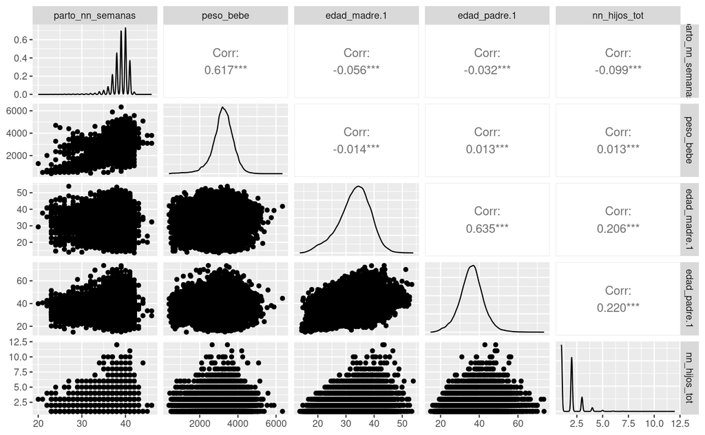

```r
#df_numeric %>% GGally::ggcorr(label = TRUE)
df_numeric %>% GGally::ggpairs()
```

- Ahora con la funciÃ³n `corrr::correlate()`

```r
df %>% select_if(is.numeric) %>%
       corrr::correlate() %>%
       pjpv2020.01::pjp_f_decimales(nn = 2) %>%
       gt::gt()
```

| term | parto_nn_semanas | peso_bebe | edad_madre.1 | edad_padre.1 | nn_hijos_tot |
| --- | --- | --- | --- | --- | --- |
| parto_nn_semanas | NA | 0.62 | -0.06 | -0.03 | -0.10 |
| peso_bebe | 0.62 | NA | -0.01 | 0.01 | 0.01 |
| edad_madre.1 | -0.06 | -0.01 | NA | 0.63 | 0.21 |
| edad_padre.1 | -0.03 | 0.01 | 0.63 | NA | 0.22 |
| nn_hijos_tot | -0.10 | 0.01 | 0.21 | 0.22 | NA |

- Otra forma mÃ¡s de visualizar las correlaciones, con `inspectdf::inspect_cor()`

```r
df %>% inspectdf::inspect_cor()
```

```
#> # A tibble: 10 Ã— 7
#>    col_1        col_2               corr   p_value    lower    upper pcnt_nna
#>    <chr>        <chr>              <dbl>     <dbl>    <dbl>    <dbl>    <dbl>
#>  1 edad_padre.1 edad_madre.1      0.635  0          0.631    0.639       96.7
#>  2 peso_bebe    parto_nn_semanas  0.617  0          0.612    0.622       89.5
#>  3 nn_hijos_tot edad_padre.1      0.220  0          0.214    0.227       96.7
#>  4 nn_hijos_tot edad_madre.1      0.206  0          0.200    0.213      100
#>  5 nn_hijos_tot parto_nn_semanas -0.0994 7.71e-159 -0.107   -0.0922      91.4
#>  6 edad_madre.1 parto_nn_semanas -0.0558 2.49e- 51 -0.0630  -0.0486      91.4
#>  7 edad_padre.1 parto_nn_semanas -0.0317 3.55e- 17 -0.0390  -0.0243      88.6
#>  8 edad_madre.1 peso_bebe        -0.0140 1.06e-  4 -0.0211  -0.00691     96.2
#>  9 edad_padre.1 peso_bebe         0.0135 2.36e-  4  0.00630  0.0207      93.2
#> 10 nn_hijos_tot peso_bebe         0.0126 5.03e-  4  0.00548  0.0196      96.2
```

- Además, después, con `inspectdf::show_plot()` se pueden visualizar las correlaciones en un gráfico:

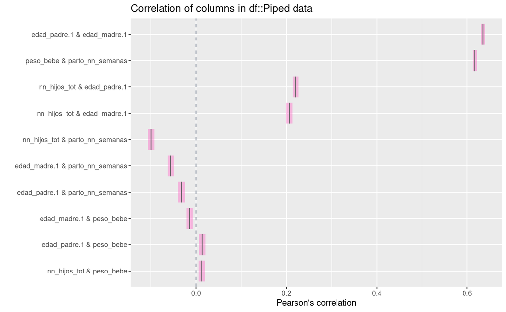

```r
df %>% inspectdf::inspect_cor() %>% inspectdf::show_plot()
```

- El paquete [correlation](https://easystats.github.io/correlation/) facilita el cálculo de diferentes estadísticos de correlación, por defecto calcula el coeficiente de correlación de Pearson:

```r
correlation::correlation(df_numeric)    #- remotes::install_github("easystats/correlation")
```

```
#> # Correlation Matrix (pearson-method)
#>
#> Parameter1       |   Parameter2 |     r |         95% CI |      t |    df |         p
#> -------------------------------------------------------------------------------------
#> parto_nn_semanas |    peso_bebe |  0.62 | [ 0.61,  0.62] | 209.62 | 71464 | < .001***
#> parto_nn_semanas | edad_madre.1 | -0.06 | [-0.06, -0.05] | -15.10 | 72993 | < .001***
#> parto_nn_semanas | edad_padre.1 | -0.03 | [-0.04, -0.02] |  -8.43 | 70752 | < .001***
#> parto_nn_semanas | nn_hijos_tot | -0.10 | [-0.11, -0.09] | -26.99 | 72993 | < .001***
#> peso_bebe        | edad_madre.1 | -0.01 | [-0.02, -0.01] |  -3.88 | 76812 | < .001***
#> peso_bebe        | edad_padre.1 |  0.01 | [ 0.01,  0.02] |   3.68 | 74416 | < .001***
#> peso_bebe        | nn_hijos_tot |  0.01 | [ 0.01,  0.02] |   3.48 | 76812 | < .001***
#> edad_madre.1     | edad_padre.1 |  0.63 | [ 0.63,  0.64] | 228.38 | 77202 | < .001***
#> edad_madre.1     | nn_hijos_tot |  0.21 | [ 0.20,  0.21] |  59.56 | 79828 | < .001***
#> edad_padre.1     | nn_hijos_tot |  0.22 | [ 0.21,  0.23] |  62.80 | 77202 | < .001***
#>
#> p-value adjustment method: Holm (1979)
#> Observations: 70754-79830
```

### d) Boxplots frente a una v. categÃ³rica

Para ver diferencias en la distribución de las variables numéricas frente a una variable categórica es muy útil `DataExplorer::plot_boxplot()`. Por ejemplo frente a la variable `estudios_madre.ff`:

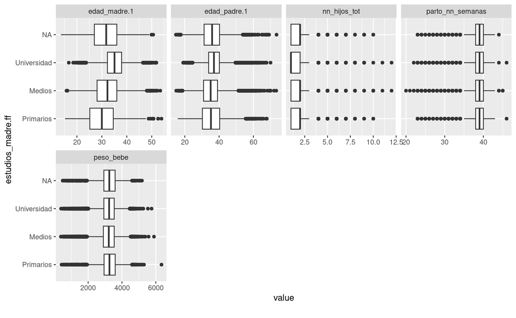

```r
DataExplorer::plot_boxplot(df, by = "estudios_madre.ff")
```

O, por ejemplo, frente a la variable `parto_cesarea.f`

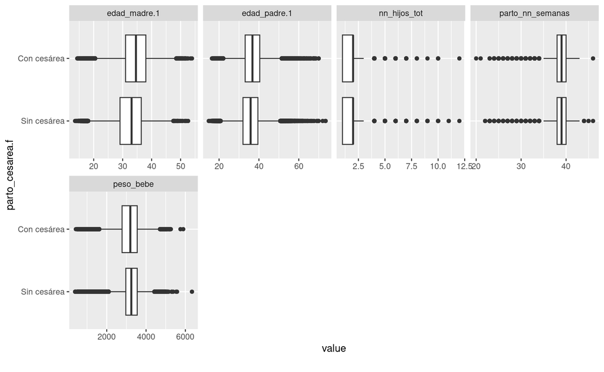

```r
my_vv <- names(df)[3]
my_vv <- "parto_cesarea.f"
DataExplorer::plot_boxplot(df, by = my_vv)
```

- También se pueden hacer boxplots de una variables numérica frente a 2 categóricas:

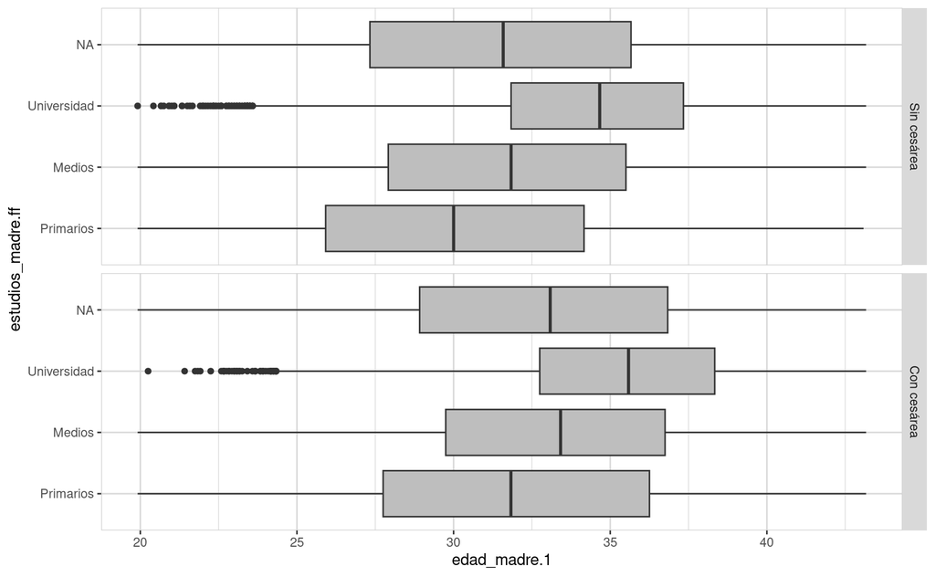

```r
df %>% explore::explore(edad_madre.1, estudios_madre.ff, target = parto_cesarea.f)
```

- Con `explore::explore_all()` se muestran grÃ¡ficos de todas las variables del df frente a una variable target u objetivo:

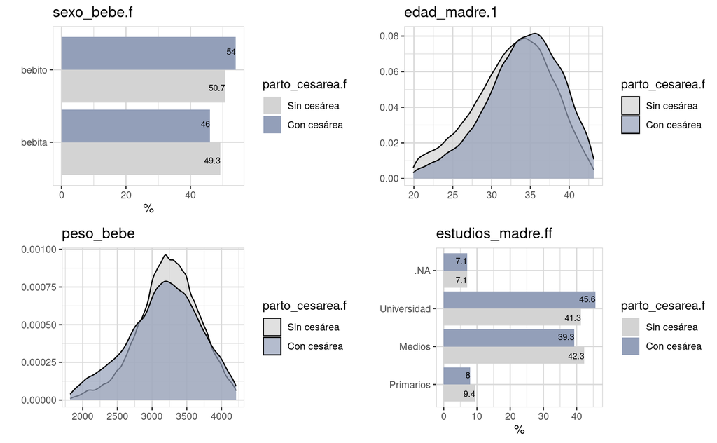

```r
df %>% select(sexo_bebe.f, edad_madre.1, peso_bebe,  estudios_madre.ff, parto_cesarea.f) %>% explore::explore_all(target = parto_cesarea.f)
```

Veamos la relación entre “estudios_madre.ff”� y CESAREA.f:

```r
df %>% janitor::tabyl(estudios_madre.ff, parto_cesarea.f) %>% janitor::adorn_percentages()
```

```
#>  estudios_madre.ff Sin cesÃ¡rea Con cesÃ¡rea
#>          Primarios   0.7322450   0.2677550
#>             Medios   0.7162494   0.2837506
#>        Universidad   0.6801212   0.3198788
#>               <NA>   0.7010455   0.2989545
```

### e) Scatterplots entre variables numÃ©ricas

`DataExplorer::plot_scatterplot()` nos permite hacer rÃ¡pidamente un scatterplot de todas las variables del df frente a una variable, por ejemplo el peso del bebe: `peso_bebe`

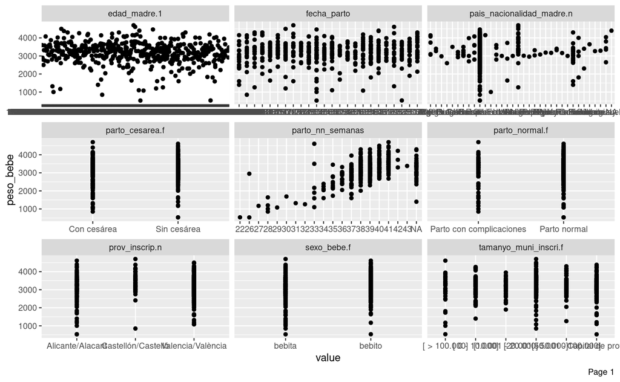

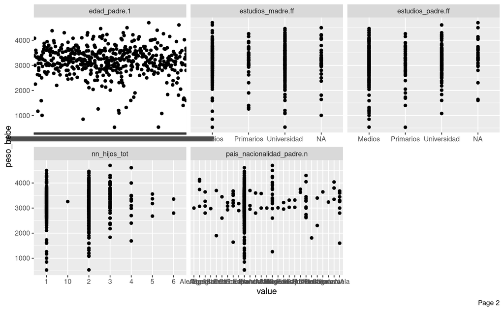

```r
my_vv <- "peso_bebe"
DataExplorer::plot_scatterplot(df, by = my_vv, sampled_rows = 500L)
```

## 3.7 Variables categÃ³ricas

Si necesitásemos un df con todas las variables categóricas, ¿cómo lo obtendrías?

```r
df %>% select_if(is.factor) %>% names()      #- old fashion
df %>% select(where(is.factor)) %>% names()
```

En realidad para seleccionar a las variables no-numéricas habría que hacer:

```r
df %>% select_if(!(is.numeric(.))) #- NO funciona
df %>% select_if(~ !is.numeric(.)) %>% names()     #- anonymous function but select_if
df %>% select(where(~ !is.numeric(.))) %>% names() #- anonymous functions & where
df %>% select(where(purrr::negate(is.numeric)))  %>% names()   #- purrr::negate()!!!!
```

Para visualizar rápidamente los valores de las variables categóricas, tenemos `inspectdf::inspect_cat()`, que nos devuelve un gráfico con la distribución de todas las variables categóricas.

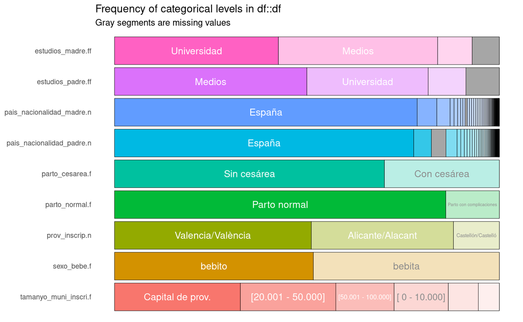

```r
inspectdf::inspect_cat(df) %>% inspectdf::show_plot(high_cardinality = 1)
```

- TambiÃ©n podemos hacerlo con `DataExplorer::plot_bar()`:

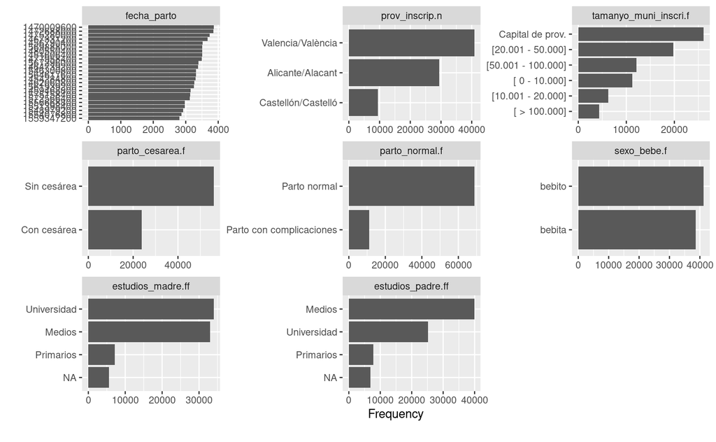

```r
DataExplorer::plot_bar(df)
```

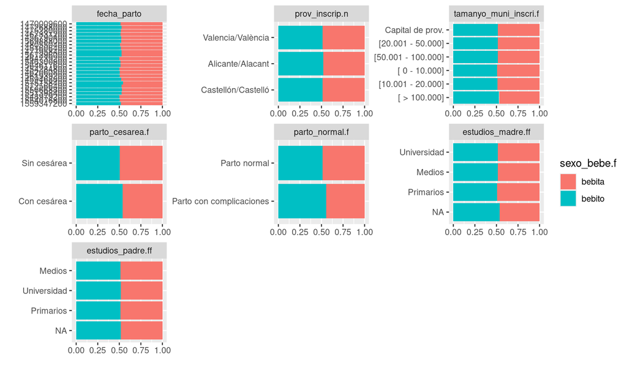

```r
DataExplorer::plot_bar(df, by = "sexo_bebe.f")
```

- O con el paquete `SmartEDA`

```r
SmartEDA::ExpCatViz(df, Page = c(3,3))
```

## 3.8 Outliers

Un *outlier* es una observación que difieres, que está alejada, del resto de observaciones. ¿Qué hacer con los *outliers*? pues como todo depende … [Aquí](https://statsandr.com/blog/outliers-detection-in-r/) y [aquí](http://r-statistics.co/Outlier-Treatment-With-R.html) tienes dos buenos posts sobre el tema.

Una forma rÃ¡pida de identificar los outliers es usar `performance::check_outliers()` o `dlookr::diagnose_outlier()`. Para imputar un valor a los *outliers* se puede utilizar `dlookr::imputate_outlier()`

## 3.9 Paquetes con shiny

### a) `burro`

El paquete [`burro`](https://github.com/laderast/burro):

> burro attempts to make EDA accessible to a larger audience by exposing datasets as a simple **Shiny App**

```r
#- devtools::install_github("laderast/burro")
df_small <- df %>% slice(1:1000)
burro::explore_data(df_small, outcome_var = colnames(df))
```

### b) `explore`

El paquete [`explore`](https://github.com/rolkra/explore).

> Instead of learning a lot of R syntax before you can explore data, the explore package enables you to have instant success. You can start with just one function - explore() - and learn other R syntax later step by step
- Podemos crear un shiny para explorar nuestro df completo:

```r
explore::explore(df)
```

- o solo explorar una o varias variables.

```r
df %>% explore::explore(parto_cesarea.f)
df %>% explore::explore(edad_madre.1, estudios_madre.ff, target = parto_cesarea.f)
```

### c) `ExPanDaR`

El paquete[ExPanDaR](https://joachim-gassen.github.io/ExPanDaR/) también permite explorar los datos a través de un shiny. Explican su funcionamiento en [este post](https://joachim-gassen.github.io/2019/12/explore-your-data-with-expand/) y [este otro](https://joachim-gassen.github.io/2019/04/customize-your-interactive-eda-explore-the-fuel-economy-of-the-u.s.-car-market/).

```r
library(ExPanDaR) #- remotes::install_github("joachim-gassen/ExPanDaR")

ExPanD(mtcars)
```

# 4. Tablas

Muchas veces hay que presentar resultados bÃ¡sicos como una tabla de casos o de frecuencias. para ello tenemos muchas posibilidades:

## 4.1 Tablas con `summarytools`

El paquete [`summarytools`](https://github.com/dcomtois/summarytools).

> `summarytools` is an R package providing tools to neatly and quickly summarize data. It can also make R a little easier to learn and to use, especially for data cleaning and preliminary analysis.
- La funciÃ³n `freq()` provee tablas con conteos y frecuencias

```r
summarytools::freq(df$sexo_bebe.f, style = "rmarkdown")
```

### Frequencies

#### df$sexo_bebe.f

**Type:** Factor

| Â | Freq | % Valid | % Valid Cum. | % Total | % Total Cum. |
| --- | --- | --- | --- | --- | --- |
| **bebita** | 38582 | 48.33 | 48.33 | 48.33 | 48.33 |
| **bebito** | 41248 | 51.67 | 100.00 | 51.67 | 100.00 |
| **<NA>** | 0 |  |  | 0.00 | 100.00 |
| **Total** | 79830 | 100.00 | 100.00 | 100.00 | 100.00 |

- tabulación cruzada entre dos variables categóricas:

```r
summarytools::ctable(df$sexo_bebe.f, df$parto_cesarea.f)
```

Cross-Tabulation, Row Proportions  
sexo_bebe.f * parto_cesarea.f  
Data Frame: df

|  | parto_cesarea.f | Sin cesárea | Con cesárea | Total |
| --- | --- | --- | --- | --- |
| sexo_bebe.f |  |  |  |  |
| bebita |  | 27599 (71.5%) | 10983 (28.5%) | 38582 (100.0%) |
| bebito |  | 28380 (68.8%) | 12868 (31.2%) | 41248 (100.0%) |
| Total |  | 55979 (70.1%) | 23851 (29.9%) | 79830 (100.0%) |

- Incluso se pueden hacer test chi-cuadrado

```r
summarytools::ctable(df$estudios_madre.ff, df$parto_normal.f, chisq = TRUE)
```

Cross-Tabulation, Row Proportions  
estudios_madre.ff * parto_normal.f  
Data Frame: df

|  | parto_normal.f | Parto normal | Parto con complicaciones | Total |
| --- | --- | --- | --- | --- |
| estudios_madre.ff |  |  |  |  |
| Primarios |  | 6167 (86.0%) | 1000 (14.0%) | 7167 (100.0%) |
| Medios |  | 28058 (84.9%) | 4971 (15.1%) | 33029 (100.0%) |
| Universidad |  | 29656 (87.2%) | 4335 (12.8%) | 33991 (100.0%) |
|  |  | 4830 (85.6%) | 813 (14.4%) | 5643 (100.0%) |
| Total |  | 68711 (86.1%) | 11119 (13.9%) | 79830 (100.0%) |

| Chi.squared | df | p.value |
| --- | --- | --- |
| 73.9143 | 2 | 0 |

## 4.2 Tablas con `janitor`

La verdad es que [`janitor`](http://sfirke.github.io/janitor/) es un paquete fantÃ¡stico!!!

> janitor has simple functions for examining and cleaning dirty data. It was built with beginning and intermediate R users in mind and is optimized for user-friendliness. Advanced R users can already do everything covered here, but with janitor they can do it faster and save their thinking for the fun stuff.
- hacer (y dar formato) a tablas de 1, 2 o 3 variables:

```r
df %>% janitor::tabyl(parto_cesarea.f) %>% gt::gt()
```

| parto_cesarea.f | n | percent |
| --- | --- | --- |
| Sin cesárea | 55979 | 0.7012276 |
| Con cesárea | 23851 | 0.2987724 |

```r
df %>% janitor::tabyl(parto_cesarea.f, estudios_madre.ff) %>% gt::gt()
```

| parto_cesarea.f | Primarios | Medios | Universidad | NA_ |
| --- | --- | --- | --- | --- |
| Sin cesárea | 5248 | 23657 | 23118 | 3956 |
| Con cesárea | 1919 | 9372 | 10873 | 1687 |

```r
df %>% janitor::tabyl(parto_cesarea.f, estudios_madre.ff, sexo_bebe.f)  #- xq no podemos usar gt::gt()
```

```
#> $bebita
#>  parto_cesarea.f Primarios Medios Universidad  NA_
#>      Sin cesÃ¡rea      2639  11639       11448 1873
#>      Con cesÃ¡rea       884   4286        5077  736
#>
#> $bebito
#>  parto_cesarea.f Primarios Medios Universidad  NA_
#>      Sin cesÃ¡rea      2609  12018       11670 2083
#>      Con cesÃ¡rea      1035   5086        5796  951
```

## 4.3 Tablas con R-base

Las tablas con R-base tampoco estÃ¡n mal. El problema que tienen es que los resultados no se almacenan en data.frames, si no en matrices.

```r
table(df$parto_cesarea.f, df$estudios_madre.ff, useNA = "always")
```

```
#>
#>               Primarios Medios Universidad  <NA>
#>   Sin cesÃ¡rea      5248  23657       23118  3956
#>   Con cesÃ¡rea      1919   9372       10873  1687
#>   <NA>                0      0           0     0
```

- Como se almacenan en matrices, para poder graficarlas con `gt` primero las hemos de convertir a data.frame y casi seguro que habrÃ¡ que hacer uso de `pivot_wider()`

```r
my_tabla <- table(df$parto_cesarea.f, df$estudios_madre.ff)
my_tabla %>% as.data.frame() %>%
            pivot_wider(names_from = 2, values_from = 3) %>%
            gt::gt()
```

| Var1 | Primarios | Medios | Universidad |
| --- | --- | --- | --- |
| Sin cesárea | 5248 | 23657 | 23118 |
| Con cesárea | 1919 | 9372 | 10873 |

- `mosaicplot()`, un grÃ¡fico que me gusta del sistema de R-base

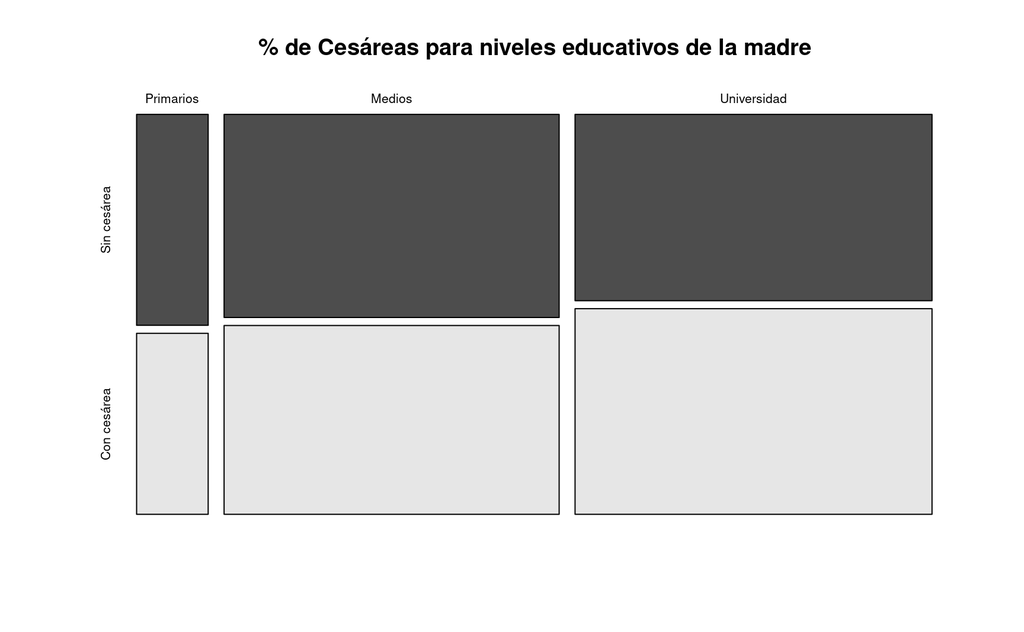

```r
zz <- prop.table(my_tabla, 1)
zz <- zz[1:2,]   #- tengo que hacer esto xq hay NA's en la tabla
mosaicplot(t(zz), color = TRUE, main = "% de CesÃ¡reas para niveles educativos de la madre")
```

# 5. Contrastes

Evidentemente R permite implementar múltiples técnicas y modelos estadísticos, así como hacer múltiples y variados contrastes de hipótesis. En [esta pagina web](https://www.statmethods.net/stats/index.html) tenéis un buena introducción a estos tema. Veamos algún ejemplo:

- `t-test`: https://statistics.berkeley.edu/computing/r-t-tests

```r
t.test(df$peso_bebe, mu = 3250)
```

```
#>
#>  One Sample t-test
#>
#> data:  df$peso_bebe
#> t = -23.744, df = 76813, p-value < 0.00000000000000022
#> alternative hypothesis: true mean is not equal to 3250
#> 95 percent confidence interval:
#>  3198.911 3206.702
#> sample estimates:
#> mean of x
#>  3202.807
```

```r
t.test(df$peso_bebe ~ df$parto_cesarea.f)
```

```
#>
#>  Welch Two Sample t-test
#>
#> data:  df$peso_bebe by df$parto_cesarea.f
#> t = 22.581, df = 34951, p-value < 0.00000000000000022
#> alternative hypothesis: true difference in means between group Sin cesÃ¡rea and group Con cesÃ¡rea is not equal to 0
#> 95 percent confidence interval:
#>   99.23847 118.10410
#> sample estimates:
#> mean in group Sin cesÃ¡rea mean in group Con cesÃ¡rea
#>                  3235.470                  3126.799
```

- correlaciÃ³n entre dos variables cuantitativas

```r
library(Hmisc)
Hmisc::rcorr(as.matrix(df_numeric))
```

- un ejemplo para ver si hay diferencias en el peso en funciÃ³n de los estudios de la madre (!!!!)

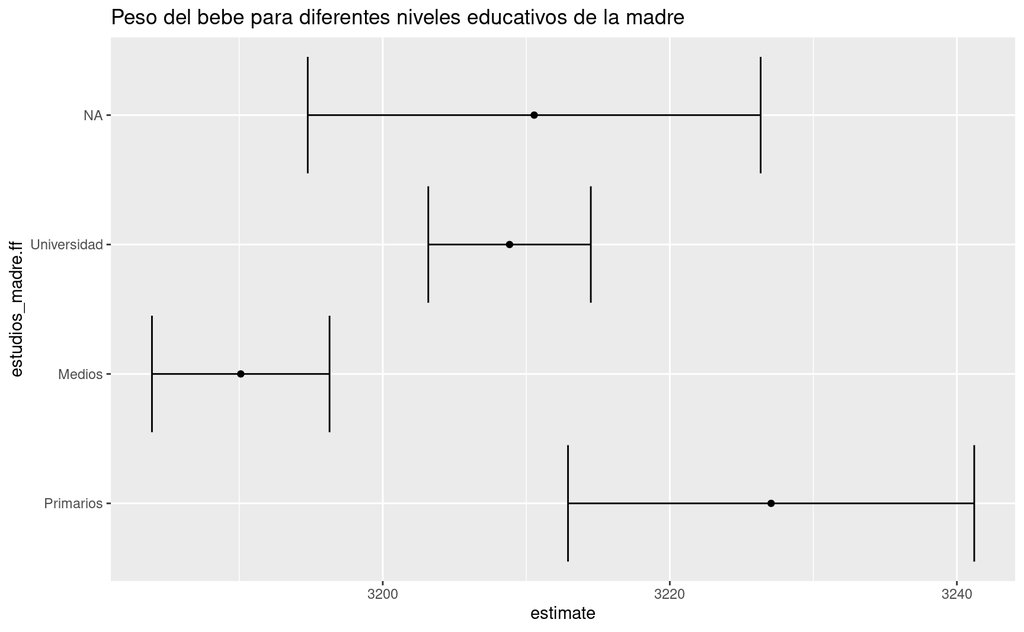

```r
library(purrr)
library(broom)
df %>% group_by(estudios_madre.ff) %>%
  summarise(t_test = list(t.test(peso_bebe))) %>%
  mutate(tidied = map(t_test, tidy)) %>%
  tidyr::unnest(tidied) %>%
  ggplot(aes(estimate, estudios_madre.ff)) + geom_point() +
  geom_errorbarh(aes(xmin = conf.low, xmax = conf.high)) +
  labs(title = "Peso del bebe para diferentes niveles educativos de la madre")
```

- `chi-squared test`: https://data-flair.training/blogs/chi-square-test-in-r/

```r
chisq.test(df$parto_cesarea.f, df$sexo_bebe.f)
```

```
#>
#>  Pearson's Chi-squared test with Yates' continuity correction
#>
#> data:  df$parto_cesarea.f and df$sexo_bebe.f
#> X-squared = 70.787, df = 1, p-value < 0.00000000000000022
```

```r
chisq.test(df$parto_cesarea.f, df$estudios_madre.ff)
```

```
#>
#>  Pearson's Chi-squared test
#>
#> data:  df$parto_cesarea.f and df$estudios_madre.ff
#> X-squared = 140.77, df = 2, p-value < 0.00000000000000022
```

- [Aquí](https://mgimond.github.io/Stats-in-R/index.html) puedes encontrar un curso sobre como implementar los contrastes estadísticos más habituales con R.

En [este post](https://lindeloev.github.io/tests-as-linear/), Jonas Kristoffer Lindeløv, nos presenta un cuadro con los contrastes de hipótesis más frecuentes y cómo efectuar esos contrastes en el contexto de los modelos de regresión con R.

# 6. Modelos

En este apartado vamos a ver (un poco[^2]) como estimar modelos lineales y no lineales con R. Para una introducción a la estimación de modelos en R puedes ir [aquí](https://m-clark.github.io/R-models/#introduction).

Además, tenemos/tengo suerte de que me puedo apoyar en lo que ya habéis visto en Econometría y otras asignaturas. El objetivo, aparte de ver como se pueden hacer análisis de regresión con R, es ir preparando el camino para introducir algo de Machine Learning.

Antes restrinjamos aún un poco más el df con los datos sobre bebes:

```r
df_m <- df %>% select(peso_bebe, parto_nn_semanas, sexo_bebe.f, parto_cesarea.f, edad_madre.1, edad_padre.1, estudios_madre.ff, estudios_padre.ff)
df_m <- df_m %>% drop_na()
```

## 6.1 Modelos lineales

La función para estimar modelos lineales es `lm()`, así que vamos a utilizarla para estimar nuestro primer modelo con R. Estimaremos un modelo lineal con variable a explicar el peso del bebe (`peso_bebe`) en función de todas las demás variables en `df_m`.

```r
mod_1 <- lm(peso_bebe ~ . , data = df_m)
summary(mod_1)
```

```
#>
#> Call:
#> lm(formula = peso_bebe ~ ., data = df_m)
#>
#> Residuals:
#>     Min      1Q  Median      3Q     Max
#> -2684.2  -272.3   -13.0   260.1  4039.2
#>
#> Coefficients:
#>                                Estimate Std. Error t value             Pr(>|t|)
#> (Intercept)                  -3690.5358    37.5808 -98.203 < 0.0000000000000002
#> parto_nn_semanas               174.4397     0.8868 196.710 < 0.0000000000000002
#> sexo_bebe.fbebito              135.8581     3.3925  40.046 < 0.0000000000000002
#> parto_cesarea.fCon cesÃ¡rea       8.3805     3.7848   2.214             0.026816
#> edad_madre.1                    -0.3357     0.4456  -0.753             0.451262
#> edad_padre.1                     2.7483     0.3799   7.234    0.000000000000475
#> estudios_madre.ffMedios        -32.8690     6.7554  -4.866    0.000001143931279
#> estudios_madre.ffUniversidad   -23.6951     7.1633  -3.308             0.000941
#> estudios_padre.ffMedios        -24.1311     6.2499  -3.861             0.000113
#> estudios_padre.ffUniversidad   -14.3470     6.9183  -2.074             0.038104
#>
#> (Intercept)                  ***
#> parto_nn_semanas             ***
#> sexo_bebe.fbebito            ***
#> parto_cesarea.fCon cesÃ¡rea   *
#> edad_madre.1
#> edad_padre.1                 ***
#> estudios_madre.ffMedios      ***
#> estudios_madre.ffUniversidad ***
#> estudios_padre.ffMedios      ***
#> estudios_padre.ffUniversidad *
#> ---
#> Signif. codes:  0 '***' 0.001 '**' 0.01 '*' 0.05 '.' 0.1 ' ' 1
#>
#> Residual standard error: 424.1 on 62688 degrees of freedom
#> Multiple R-squared:  0.3956, Adjusted R-squared:  0.3955
#> F-statistic:  4559 on 9 and 62688 DF,  p-value: < 0.00000000000000022
```

Generalmente las **variables categóricas** se introducen en los modelos mediante **variables dummies**. Crear dummies en R es sencillo, solo tienes que tener los datos como factor o como texto y R creará las dummies por ti cuando introduzcas la variable en `lm()`. Eso sí, es más fácil elegir la categoría de referencia si la variable es un factor.

Para entender como fija los regresores para las variables categÃ³ricas, mira esto:

```r
levels(df$sexo_bebe.f)
```

```
#> [1] "bebita" "bebito"
```

```r
levels(df$estudios_madre.ff)
```

```
#> [1] "Primarios"   "Medios"      "Universidad"
```

Si necesitas cambiar la categorÃa de referencia siempre puedes usar `forcast::fct_relevel()`

```r
zz <- forcats::fct_relevel(df$sexo_bebe.f, "bebito")
levels(zz)
```

```
#> [1] "bebito" "bebita"
```

Veamos que hay en el objeto `mod_1`

```r
str(mod_1)
#listviewer::jsonedit(mod_1, mode = "view") ## Interactive option
```

#### EspecificaciÃ³n del modelo

LÃ³gicamente, a veces querremos seleccionar las variables explicativas:

```r
mod_1 <- lm(peso_bebe ~ parto_nn_semanas, data = df_m)
mod_1 <- lm(peso_bebe ~ parto_nn_semanas + sexo_bebe.f + parto_cesarea.f + edad_madre.1 , data = df_m)
mod_1 <- lm(log(peso_bebe) ~ log(parto_nn_semanas), data = df_m)

summary(mod_1)
```

```
#>
#> Call:
#> lm(formula = log(peso_bebe) ~ log(parto_nn_semanas), data = df_m)
#>
#> Residuals:
#>      Min       1Q   Median       3Q      Max
#> -1.67055 -0.08264  0.00416  0.09018  1.63927
#>
#> Coefficients:
#>                       Estimate Std. Error t value            Pr(>|t|)
#> (Intercept)           -1.37399    0.03976  -34.55 <0.0000000000000002 ***
#> log(parto_nn_semanas)  2.57713    0.01087  237.14 <0.0000000000000002 ***
#> ---
#> Signif. codes:  0 '***' 0.001 '**' 0.01 '*' 0.05 '.' 0.1 ' ' 1
#>
#> Residual standard error: 0.1465 on 62696 degrees of freedom
#> Multiple R-squared:  0.4728, Adjusted R-squared:  0.4728
#> F-statistic: 5.624e+04 on 1 and 62696 DF,  p-value: < 0.00000000000000022
```

Si queremos introducir interacciones entre los regresores, podemos usar el operador `:`, aunque casi mejor hacerlo directamente con `I()`:

```r
mod_1 <- lm(peso_bebe ~ parto_nn_semanas + parto_nn_semanas:edad_madre.1, data = df_m)
mod_1 <- lm(peso_bebe ~ parto_nn_semanas + I(parto_nn_semanas*edad_madre.1), data = df_m)

summary(mod_1)
```

```
#>
#> Call:
#> lm(formula = peso_bebe ~ parto_nn_semanas + I(parto_nn_semanas *
#>     edad_madre.1), data = df_m)
#>
#> Residuals:
#>     Min      1Q  Median      3Q     Max
#> -2663.1  -277.3   -14.2   263.2  4067.8
#>
#> Coefficients:
#>                                        Estimate   Std. Error  t value
#> (Intercept)                        -3525.030516    34.468503 -102.268
#> parto_nn_semanas                     171.637088     0.912705  188.053
#> I(parto_nn_semanas * edad_madre.1)     0.046324     0.008384    5.526
#>                                                Pr(>|t|)
#> (Intercept)                        < 0.0000000000000002 ***
#> parto_nn_semanas                   < 0.0000000000000002 ***
#> I(parto_nn_semanas * edad_madre.1)          0.000000033 ***
#> ---
#> Signif. codes:  0 '***' 0.001 '**' 0.01 '*' 0.05 '.' 0.1 ' ' 1
#>
#> Residual standard error: 429.9 on 62695 degrees of freedom
#> Multiple R-squared:  0.379,  Adjusted R-squared:  0.3789
#> F-statistic: 1.913e+04 on 2 and 62695 DF,  p-value: < 0.00000000000000022
```

Si queremos introducir las variables originales y tambiÃ©n las interacciones entre ellas, podemos hacerlo directamente o o utilizar el operador `*`:

```r
mod_1 <- lm(peso_bebe ~ parto_nn_semanas + edad_madre.1 + parto_nn_semanas:edad_madre.1, data = df_m)
mod_1 <- lm(peso_bebe ~ parto_nn_semanas + edad_madre.1 + I(parto_nn_semanas*edad_madre.1), data = df_m)
mod_1 <- lm(peso_bebe ~ parto_nn_semanas*edad_madre.1, data = df_m)
mod_1 <- lm(peso_bebe ~ parto_nn_semanas*estudios_madre.ff, data = df_m)

summary(mod_1)
```

```
#>
#> Call:
#> lm(formula = peso_bebe ~ parto_nn_semanas * estudios_madre.ff,
#>     data = df_m)
#>
#> Residuals:
#>     Min      1Q  Median      3Q     Max
#> -2662.5  -278.4   -14.4   263.6  4077.9
#>
#> Coefficients:
#>                                                 Estimate Std. Error t value
#> (Intercept)                                   -3454.8834   114.2206 -30.247
#> parto_nn_semanas                                172.0883     2.9322  58.689
#> estudios_madre.ffMedios                         -74.5179   124.9941  -0.596
#> estudios_madre.ffUniversidad                    -52.2686   125.2082  -0.417
#> parto_nn_semanas:estudios_madre.ffMedios          0.9322     3.2094   0.290
#> parto_nn_semanas:estudios_madre.ffUniversidad     0.7607     3.2149   0.237
#>                                                          Pr(>|t|)
#> (Intercept)                                   <0.0000000000000002 ***
#> parto_nn_semanas                              <0.0000000000000002 ***
#> estudios_madre.ffMedios                                     0.551
#> estudios_madre.ffUniversidad                                0.676
#> parto_nn_semanas:estudios_madre.ffMedios                    0.771
#> parto_nn_semanas:estudios_madre.ffUniversidad               0.813
#> ---
#> Signif. codes:  0 '***' 0.001 '**' 0.01 '*' 0.05 '.' 0.1 ' ' 1
#>
#> Residual standard error: 429.9 on 62692 degrees of freedom
#> Multiple R-squared:  0.3791, Adjusted R-squared:  0.379
#> F-statistic:  7655 on 5 and 62692 DF,  p-value: < 0.00000000000000022
```

Recuerda que si queremos introducir algún regresor que sea la multiplicación de dos variables, tendremos que hacerlo con `I()`

```r
mod_1 <- lm(peso_bebe ~ parto_nn_semanas + I(parto_nn_semanas*parto_nn_semanas), data = df_m)

summary(mod_1)
```

```
#>
#> Call:
#> lm(formula = peso_bebe ~ parto_nn_semanas + I(parto_nn_semanas *
#>     parto_nn_semanas), data = df_m)
#>
#> Residuals:
#>     Min      1Q  Median      3Q     Max
#> -2634.3  -276.6   -14.3   262.8  4317.7
#>
#> Coefficients:
#>                                          Estimate Std. Error t value
#> (Intercept)                            -5768.0193   228.5009  -25.24
#> parto_nn_semanas                         297.0664    12.4745   23.81
#> I(parto_nn_semanas * parto_nn_semanas)    -1.6984     0.1702   -9.98
#>                                                   Pr(>|t|)
#> (Intercept)                            <0.0000000000000002 ***
#> parto_nn_semanas                       <0.0000000000000002 ***
#> I(parto_nn_semanas * parto_nn_semanas) <0.0000000000000002 ***
#> ---
#> Signif. codes:  0 '***' 0.001 '**' 0.01 '*' 0.05 '.' 0.1 ' ' 1
#>
#> Residual standard error: 429.7 on 62695 degrees of freedom
#> Multiple R-squared:  0.3796, Adjusted R-squared:  0.3796
#> F-statistic: 1.918e+04 on 2 and 62695 DF,  p-value: < 0.00000000000000022
```

También puede sernos de utilidad la función `poly()`

```r
mod_1 <- lm(peso_bebe ~ poly(parto_nn_semanas, degree = 3), data = df_m)

summary(mod_1)
```

```
#>
#> Call:
#> lm(formula = peso_bebe ~ poly(parto_nn_semanas, degree = 3),
#>     data = df_m)
#>
#> Residuals:
#>     Min      1Q  Median      3Q     Max
#> -2663.2  -273.2   -12.8   256.8  3608.3
#>
#> Coefficients:
#>                                       Estimate Std. Error t value
#> (Intercept)                           3205.032      1.703 1881.65
#> poly(parto_nn_semanas, degree = 3)1  84052.196    426.500  197.07
#> poly(parto_nn_semanas, degree = 3)2  -4287.939    426.500  -10.05
#> poly(parto_nn_semanas, degree = 3)3 -13032.791    426.500  -30.56
#>                                                Pr(>|t|)
#> (Intercept)                         <0.0000000000000002 ***
#> poly(parto_nn_semanas, degree = 3)1 <0.0000000000000002 ***
#> poly(parto_nn_semanas, degree = 3)2 <0.0000000000000002 ***
#> poly(parto_nn_semanas, degree = 3)3 <0.0000000000000002 ***
#> ---
#> Signif. codes:  0 '***' 0.001 '**' 0.01 '*' 0.05 '.' 0.1 ' ' 1
#>
#> Residual standard error: 426.5 on 62694 degrees of freedom
#> Multiple R-squared:  0.3888, Adjusted R-squared:  0.3887
#> F-statistic: 1.329e+04 on 3 and 62694 DF,  p-value: < 0.00000000000000022
```

#### Resultados de estimaciÃ³n

Una vez que sabemos la sintaxis de `stats::lm()`, vamos a ver como podemos acceder a la información que devuelve `lm()`. Ya hemos visto que los resultados se almacenan en una lista, así que podemos utilizar los operadores habituales de las listas para acceder a la información. Por ejemplo:

```r
zz_betas     <- mod_1[[1]]

zz_residuals <- mod_1[[2]]
zz_residuals <- mod_1[["residuals"]]
zz_residuals <- mod_1$residuals

zz_betas_1   <- mod_1[[1]]      #- [[ ]] doble corchete
zz_betas_2 <- mod_1[1]          #- []    corchete simple

zz_betas_1a <- mod_1[["coefficients"]]   #- doble corchete
zz_betas_1c <- mod_1$coefficients        #- $

zz_betas_2a <- mod_1["coefficients"]     #- single corchete
```

Afortunadamente ya hay construidas algunas funciones para manipular/ver los resultados de estimaciÃ³n. Por ejemplo:

```r
mod_1 <- lm(peso_bebe ~ parto_nn_semanas + edad_madre.1 + sexo_bebe.f , data = df_m)

summary(mod_1)                   #- tabla resumen
summary(mod_1)$coefficients      #- tabla resumen con los coeficientes
coefficients(mod_1)              #- coeficientes estimados
confint(mod_1, level = 0.95)     #- Intervalos de confianza para los coeficientes
#fitted(mod_1)                   #- predicciones (y-sombrero, y-hat)
#residuals(mod_1)                #- vector de residuos
#model.matrix(mod_1)             #- extract the model matrix
anova(mod_1)                     #- ANOVA
vcov(mod_1)                      #- matriz de var-cov para los coeficientes
#influence(mod_1)                #- regression diagnostics
# diagnostic plots
layout(matrix(c(1, 2, 3, 4), 2, 2))   #- optional 4 graphs/page
plot(mod_1)                      #-
library(ggfortify)
autoplot(mod_1, which = 1:6, ncol = 2, colour = "steelblue")
```

#### MÃ¡s utilidades

Hay muchas más funciones para valorar la idoneidad de un modelo. Por ejemplo [aquí](https://www.statmethods.net/stats/rdiagnostics.html).

El paquete [`GGally`](https://ggobi.github.io/ggally/) permite hacer muchos anÃ¡lisis, por ejemplo:

- grÃ¡fico de los coeficientes estimados

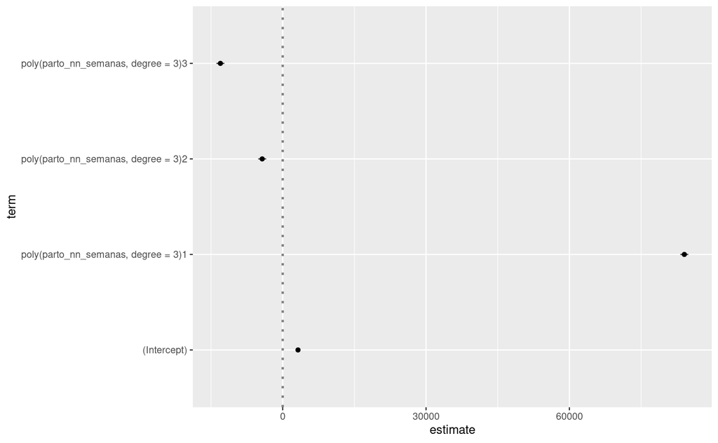

```r
GGally::ggcoef(mod_1)
```

- y muchas mÃ¡s cosas

```r
df_jugar <- df_m %>% select(edad_madre.1, sexo_bebe.f, parto_nn_semanas)
GGally::ggpairs(df_jugar)
```

[figure not shown]

# Esto es un tÃtulo de primer nivel

## 1. Esto es un tÃtulo de segundo nivel

## 2. Formateo de texto

Esto es texo normal

**Esto se mostrarÃ¡ en negrita**

*Esto se mostrarÃ¡ en cursiva*

Esto se mostrarÃ¡ tachado

> Esto se mostrarÃ¡ como una cita

## 3. Listas

Listas con nÃºmeros:

1. Primero
2. Segundo
3. Tercero

Listas con bullets:

- Primero
- segundo
- Tercero

Mas listas:

1. Primero
   - 1.1
   - 1.2
2. Segundo
   - a
   - b
3. Tercero

### Sub-indices y ..

Un superÃndice: Y<sup>2</sup>

Un subÃndice: Y<sub>2</sub>

### ImÃ¡genes

Para mostrar una imÃ¡gen basta con:

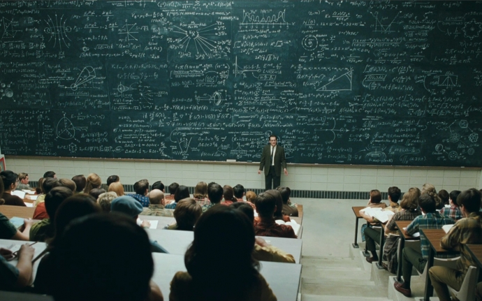

También podríamos haberlo hecho así (da un poco más flexibilidad):

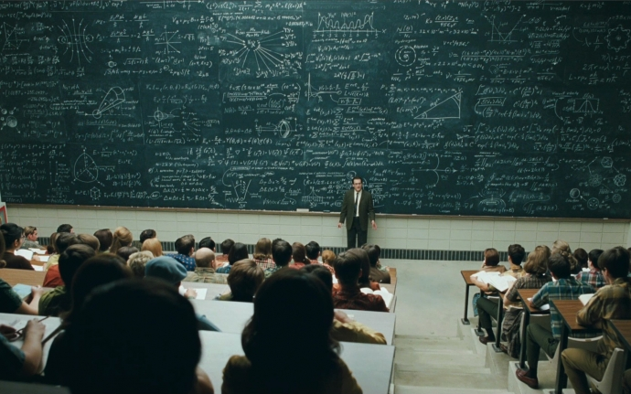

### Formulas

Las formulas hay que escribirlas en Latex. Yo no sÃ© mucho Latex, pero hay editores que facilitan mucho el trabajo: preguntad al profe!!

Una fórmula dentro del texto se escribiría así: $E = mc^{2}$ ; es decir, enmarcándola por `$`

Si quieres la formula ella sola hay que poner dos `$$`:

$$E = mc^{2}$$

### Hyperlinks

Esto es un hyperlink: http://www.wikipedia.es

Pero es mejor ponerlo asÃ: [enlace a la Wikipedia](http://www.wikipedia.es)

### Notas al pie de pÃ¡gina

Para poner notas al pie has de poner [^1]

### Tablas

Habrá un tutorial especifico para tablas, pero lo más básico y sencillo es con la función `kable()`:

```r
knitr::kable(summary(iris))
```

|  | Sepal.Length | Sepal.Width | Petal.Length | Petal.Width | Species |
| --- | --- | --- | --- | --- | --- |
|  | Min. :4.300 | Min. :2.000 | Min. :1.000 | Min. :0.100 | setosa :50 |
|  | 1st Qu.:5.100 | 1st Qu.:2.800 | 1st Qu.:1.600 | 1st Qu.:0.300 | versicolor:50 |
|  | Median :5.800 | Median :3.000 | Median :4.350 | Median :1.300 | virginica :50 |
|  | Mean :5.843 | Mean :3.057 | Mean :3.758 | Mean :1.199 | NA |
|  | 3rd Qu.:6.400 | 3rd Qu.:3.300 | 3rd Qu.:5.100 | 3rd Qu.:1.800 | NA |
|  | Max. :7.900 | Max. :4.400 | Max. :6.900 | Max. :2.500 | NA |

## 5. Aún más cosas

Hay más cosas, como referencias bibliográficas, pero ya será para el segundo curso de R.

A pesar de que Markdown permite formatear el texto, en ciertos sentidos es limitado; pero si quieres aún más flexibilidad en el output, tendrás que aprender html y mejor html+CSS.

Algunos ejemplos:

1. Si quieres introducir un párrafo en otro color tendrás que hacerlo en html

Esto se mostrarÃ¡ en ROJO!!

2. si quieres centrar un pÃ¡rrafo.

Este párrafo irá centrado

3. Una pagina web

[interactive chart not shown]

4. Un vÃdeo

[video not shown]

[^1]: esto es una nota al pie.